# Nobel_Prize

**Unveiling Excellence: A Deep Dive into the Nobel Prize Laureates Dataset**

**Introduction:**

A deep dive into the Nobel dataset reveals much about those who've gained its top honor since day one. Names, where they were born and died, and whether they are male or female - all these facts are there. Also noted: what award was given out; when it happened; why they earned it; where they worked at that time. This study's goal is to sift through such data for clues on trends among these high achievers. With Python's help (and its toolkit for slicing up info), this task will show us more than just past patterns—it'll cast light on how global praise shifts across sectors over time. The code crafted here aims to find links between frequent winners, their home spots, and gender splits in the victory ranks. As we map out awards by type, place of origin, institution ties – our search will pull back layers from Nobel Prize lore. Insights await as we parse this rich field with skillful precision: a quest for knowledge underpinned by an intricate web of data points spanning years of intellectual triumphs.

Questions:

1. Top 10 Individuals with the Most Nobel Prizes
2. Top 10 Countries with the Most Nobel Winners
3. Top 5 Most Common Universities among Nobel Winners
4. Gender Distribution among Nobel Winners
5. Categories with the Most Winners
6. Nobel Winners Who Are Still Alive
7. Nobel Winners Who Died Before the 21st Century
8. Nobel Winners Who Died in the 21st Century

```python
import pandas as pd
import matplotlib.pyplot as plt
import seaborn as sns

df_nobel = pd.read_csv("nobel.csv")
```

```python
df_nobel.columns
```

```
Index(['id', 'firstname', 'surname', 'born', 'died', 'bornCountry',
       'bornCountryCode', 'bornCity', 'diedCountry', 'diedCountryCode',
       'diedCity', 'gender', 'year', 'category', 'overallMotivation', 'share',
       'motivation', 'name', 'city', 'country'],
      dtype='object')
```

```python
df_nobel.head()
```

|  | id | firstname | surname | born | died | bornCountry | bornCountryCode | bornCity | diedCountry | diedCountryCode | diedCity | gender | year | category | overallMotivation | share | motivation | name | city | country |
| --- | --- | --- | --- | --- | --- | --- | --- | --- | --- | --- | --- | --- | --- | --- | --- | --- | --- | --- | --- | --- |
| 0 | 1 | Wilhelm Conrad | Röntgen | 1845-03-27 | 1923-02-10 | Prussia (now Germany) | DE | Lennep (now Remscheid) | Germany | DE | Munich | male | 1901 | physics | NaN | 1 | "in recognition of the extraordinary services ... | Munich University | Munich | Germany |
| 1 | 2 | Hendrik A. | Lorentz | 1853-07-18 | 1928-02-04 | the Netherlands | NL | Arnhem | the Netherlands | NL | NaN | male | 1902 | physics | NaN | 2 | "in recognition of the extraordinary service t... | Leiden University | Leiden | the Netherlands |
| 2 | 3 | Pieter | Zeeman | 1865-05-25 | 1943-10-09 | the Netherlands | NL | Zonnemaire | the Netherlands | NL | Amsterdam | male | 1902 | physics | NaN | 2 | "in recognition of the extraordinary service t... | Amsterdam University | Amsterdam | the Netherlands |
| 3 | 4 | Henri | Becquerel | 1852-12-15 | 1908-08-25 | France | FR | Paris | France | FR | NaN | male | 1903 | physics | NaN | 2 | "in recognition of the extraordinary services ... | École Polytechnique | Paris | France |
| 4 | 5 | Pierre | Curie | 1859-05-15 | 1906-04-19 | France | FR | Paris | France | FR | Paris | male | 1903 | physics | NaN | 4 | "in recognition of the extraordinary services ... | École municipale de physique et de chimie indu... | Paris | France |

```python
df_nobel.tail()
```

|  | id | firstname | surname | born | died | bornCountry | bornCountryCode | bornCity | diedCountry | diedCountryCode | diedCity | gender | year | category | overallMotivation | share | motivation | name | city | country |
| --- | --- | --- | --- | --- | --- | --- | --- | --- | --- | --- | --- | --- | --- | --- | --- | --- | --- | --- | --- | --- |
| 995 | 1030 | Louis | Brus | 1943-00-00 | 0000-00-00 | USA | US | Cleveland OH | NaN | NaN | NaN | male | 2023 | chemistry | NaN | 3 | "for the discovery and synthesis of quantum dots" | Columbia University | New York NY | USA |
| 996 | 1031 | Aleksey | Yekimov | 1945-00-00 | 0000-00-00 | USSR (now Russia) | RU | NaN | NaN | NaN | NaN | male | 2023 | chemistry | NaN | 3 | "for the discovery and synthesis of quantum dots" | Nanocrystals Technology Inc. | New York NY | USA |
| 997 | 1032 | Jon | Fosse | 1959-09-29 | 0000-00-00 | Norway | NO | Haugesund | NaN | NaN | NaN | male | 2023 | literature | NaN | 1 | "for his innovative plays and prose which give... | NaN | NaN | NaN |
| 998 | 1033 | Narges | Mohammadi | 1972-04-21 | 0000-00-00 | Iran | IR | Zanjan | NaN | NaN | NaN | female | 2023 | peace | NaN | 1 | "for her fight against the oppression of women... | NaN | NaN | NaN |
| 999 | 1034 | Claudia | Goldin | 1946-00-00 | 0000-00-00 | USA | US | New York NY | NaN | NaN | NaN | female | 2023 | economics | NaN | 1 | "for having advanced our understanding of wome... | Harvard University | Cambridge MA | USA |

```python
df_nobel.shape
```

```
(1000, 20)
```

Top 10 individuals with the most Nobel prizes

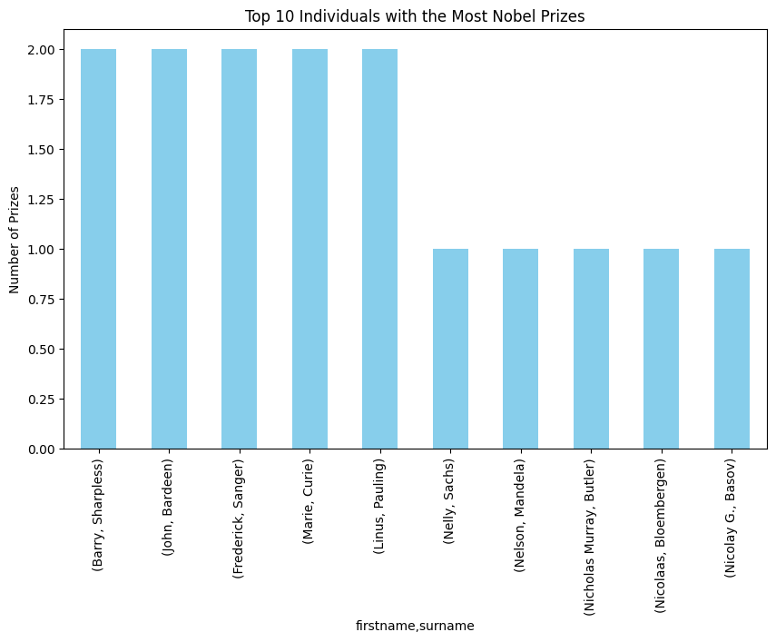

```python
top_individuals = df_nobel.groupby(['firstname', 'surname']).size().sort_values(ascending=False).head(10)
plt.figure(figsize=(10, 6))
top_individuals.plot(kind='bar', color='skyblue')
plt.title('Top 10 Individuals with the Most Nobel Prizes')
plt.ylabel('Number of Prizes')
plt.show()
```

Top 10 countries with the most Nobel prize winners

```python
top_countries = df_nobel['bornCountry'].value_counts().head(10)
print(top_countries.to_frame('Number of Nobel Prize Winners'))
```

```
                 Number of Nobel Prize Winners
USA                                        292
United Kingdom                              90
Germany                                     67
France                                      58
Sweden                                      30
Japan                                       28
Canada                                      21
the Netherlands                             19
Switzerland                                 19
Russia                                      18
```

Top 5 universities that produced the most Nobel Prize winners

```python
top_universities = df_nobel['name'].value_counts().head(5)
print(top_universities.to_frame('Number of Nobel Prize Winners'))
```

```
                                             Number of Nobel Prize Winners
University of California                                                36
Harvard University                                                      28
Stanford University                                                     22
Massachusetts Institute of Technology (MIT)                             22
University of Chicago                                                   19
```

The Gender distribution of the Nobel Prize winners

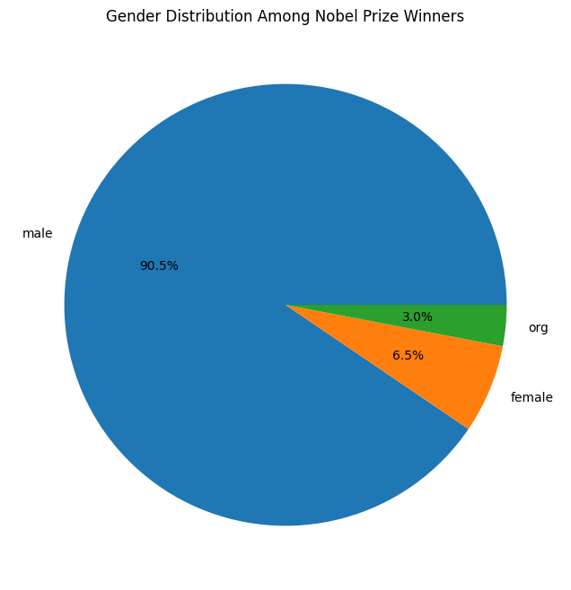

```python
gender_distribution = df_nobel['gender'].value_counts()
plt.figure(figsize=(8, 8))
gender_distribution.plot(kind='pie', autopct='%1.1f%%')
plt.title('Gender Distribution Among Nobel Prize Winners')
plt.ylabel('')
plt.show()
```

The categories that have the most Nobel Prize winners under their belt

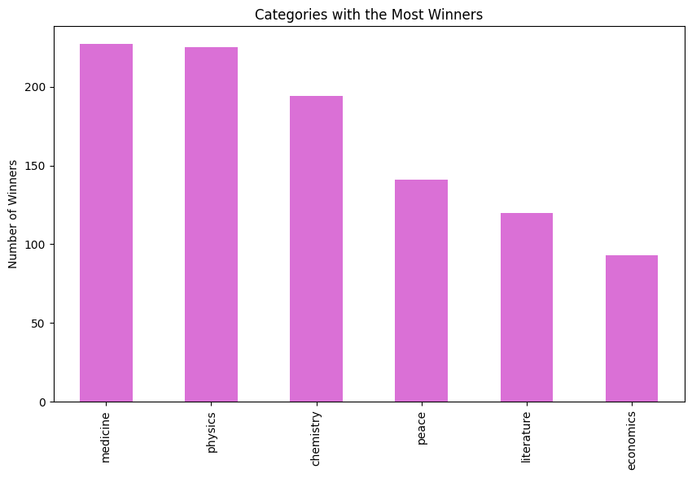

```python
categories_count = df_nobel['category'].value_counts()
plt.figure(figsize=(10, 6))
categories_count.plot(kind='bar', color='orchid')
plt.title('Categories with the Most Winners')
plt.ylabel('Number of Winners')
plt.show()
```

Nobel Prize winners who are still alive today

```python
df_nobel['born'] = pd.to_datetime(df_nobel['born'], errors='coerce')
df_nobel['died'] = pd.to_datetime(df_nobel['died'], errors='coerce')
```

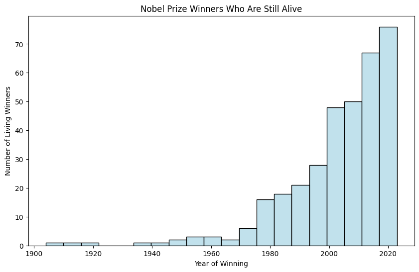

```python
current_year = pd.to_datetime('now').year
living_laureates = df_nobel[(df_nobel['died'].isna()) | (df_nobel['died'].dt.year >= current_year)]
living_count = living_laureates['category'].value_counts()
plt.figure(figsize=(10, 6))
sns.histplot(living_laureates['year'], bins=20, kde=False, color='lightblue')
plt.title('Nobel Prize Winners Who Are Still Alive')
plt.xlabel('Year of Winning')
plt.ylabel('Number of Living Winners')
plt.show()
```

Nobel Prize Winners who died before the 21st Century

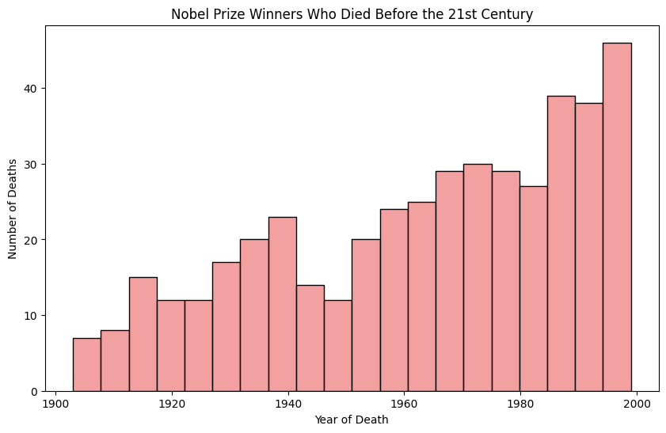

```python
died_before_21st = df_nobel[(df_nobel['died'].dt.year < 2000) & (df_nobel['died'].dt.year.notna())]
plt.figure(figsize=(10, 6))
sns.histplot(died_before_21st['died'].dt.year, bins=20, kde=False, color='lightcoral')
plt.title('Nobel Prize Winners Who Died Before the 21st Century')
plt.xlabel('Year of Death')
plt.ylabel('Number of Deaths')
plt.show()
```

Nobel Prize Winners who have died in the 21st Century

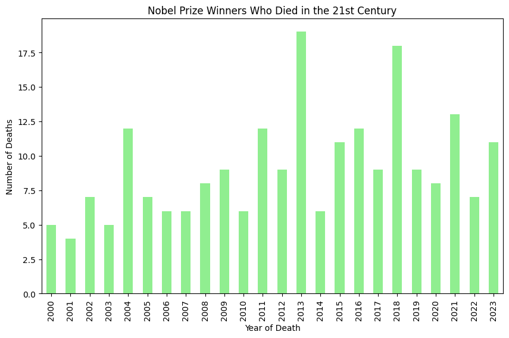

```python
died_in_21st = df_nobel[df_nobel['died'].dt.year >= 2000]
death_count_in_21st = died_in_21st['died'].dt.year.value_counts().sort_index()
plt.figure(figsize=(10, 6))
death_count_in_21st.plot(kind='bar', color='lightgreen')
plt.title('Nobel Prize Winners Who Died in the 21st Century')
plt.xlabel('Year of Death')
plt.ylabel('Number of Deaths')
plt.show()
```

**Insights:**

**1. Dominance and Prominence of Certain Individuals and Fields:** The analysis of individuals with the most Nobel Prizes highlights key figures who have made significant contributions in their fields. This could indicate areas where groundbreaking work is happening or where further research and innovation are needed. data highlights that a few individuals have won multiple Nobel Prizes, emphasizing the rarity and prestige of the award.

**2. Geographical Concentration of Nobel Laureates:** The top countries producing Nobel laureates reveal global centers of excellence and innovation. This suggests that these regions may have robust educational and research infrastructures that foster groundbreaking work. This may also reflect the quality of education, level of research funding, and cultural emphasis on scientific and literary pursuits in these countries.

**3. Influential Educational Institutions as Innovation Hubs:** The presence of specific universities among the top common institutions for Nobel winners underscores the role of academic institutions in driving research and development. Also, underlines their role as epicenters of groundbreaking research and innovation. This could serve as a guide for aspiring researchers in choosing their academic and research affiliations.

**4.Gender Disparity in Nobel Laureates:** The gender distribution among Nobel laureates highlights the existing gender gap in recognition within the scientific and academic communities, pointing to a need for greater diversity and inclusion. This could point towards historical and systemic barriers in academia and research fields for women, warranting more efforts for gender equality.

**5.Trends in Nobel Prize Categories:** The distribution of prizes across different categories provides insights into the areas that have historically received more attention and funding.

**6. LLiving Legends:** The count of Nobel laureates who are still alive offers a glimpse into the living legends among us. Their ongoing work and influence continue to shape their respective fields. Furthermore, reflects the ongoing evolution and relevance of the Nobel Prize in recognizing contemporary contributions.

**7. Historical Perspective** The analysis of Nobel laureates who died before the 21st century versus those who died in the 21st century offers a historical perspective. It reflects the evolution of the Nobel Prize over time and the changing demographics of its recipients.

**Conclusion:**

To wrap things up, when we pore over the Nobel Prize records, stark truths emerge. A few stand tall among the crowd; certain folks and nations with a knack for making their mark time and again in their chosen realms—these are the ones bathed in glory's light. And yet, amidst these tales of triumph lurk shadows: fewer women hold that coveted title, exposing gaps that need mending. Powerhouse universities prove crucial too; they nurture minds bound for greatness. As we sift through names both past and present across eras diverse, patterns shift like sands—the quest for knowledge knows no bounds but takes new forms with each dawn. These findings paint a rich tableau of what it means to reach pinnacles of achievement on this world stage. They signal how vital it is to weave strands of diversity into the fabric from which future Nobel laureates will be cut.